# NLP - Natural Language Processing

```python
# packages
import re
import string
import numpy as np
import pandas as pd
import seaborn as sns
import tensorflow as tf
import matplotlib.pyplot as plt

from nltk.tokenize import  TweetTokenizer
from nltk.stem import PorterStemmer as porter
from sklearn.feature_extraction.text import CountVectorizer

import wordcloud
from sklearn.decomposition import LatentDirichletAllocation


FS = 12 # fontsize for plots
```

```python
### Defined functions ###
def sort_a_dict(dictionary, reverse=True):
    return dict(sorted(dictionary.items(), key=lambda item: item[1], reverse=reverse))


def count_words(list_of_words):
    count = {}
    for w in list_of_words:
        if w in count.keys():
            count[w] += 1
        else:
            count[w] = 1
    return sort_a_dict(count)


def select_same_keys(dict1, dict2, min_value=1e-3):
    same_keys = {}
    for key in dict1:
        if key in dict2:
            if dict1[key] >= min_value and dict2[key] >= min_value:
                same_keys[key] = (dict1[key], dict2[key])
    return same_keys


def count_pctg(dictionary):
    return {key: value/sum(dictionary.values()) for key, value in dictionary.items()}
```

## Exercise 1

Read in a bunch of tweets that were collected during the airing of the 'Red Wedding' episode of Game of Thrones from the file `got_tweets.csv`.

Parse all the hashtags out of the texts, then count their overall occurrences. What are the 10 most common hashtags? Make a bar chart of these top 10 hashtags! Create a plot of hashtag timelines for the most interesting and frequent hashtags!

```python
fname="./D-NLP/got_tweets.csv"
df = pd.read_csv(fname)
text = df.text

if sum(df.text.isna()) == 0:
    print("There are no missing text records.")
else:
    print("There are missing records, clear it!")
```

```
There are no missing text records.
```

```python
hashtags = []
for tw in text:
    hashtags.append([i[1:].lower() for i in tw.split() if i.startswith("#")])
hashtags = [w for sublist in hashtags for w in sublist]

# remove all punctuation from hashtags
hashtags = ['#' + ''.join(c for c in h if c not in string.punctuation) for h in hashtags]
hashtag_count = count_words(hashtags)
```

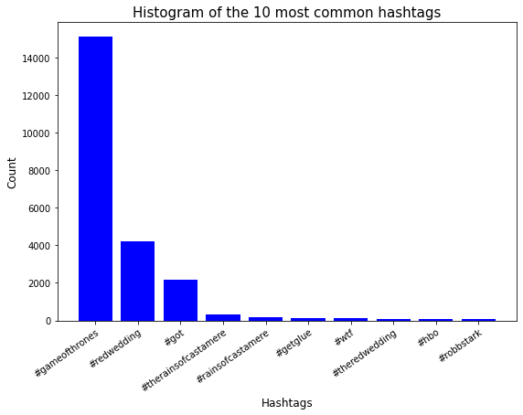

```python
num_of_bars = 10
plt.figure(figsize=(9,6))
plt.bar(np.arange(0, num_of_bars), list(hashtag_count.values())[:num_of_bars], color='b')
plt.xticks(np.arange(0, num_of_bars), list(hashtag_count.keys())[:num_of_bars], rotation=35, ha='right', rotation_mode='anchor')
plt.title(f'Histogram of the {num_of_bars} most common hashtags', fontsize=FS+3)
plt.xlabel('Hashtags', fontsize=FS)
plt.ylabel('Count', fontsize=FS)
plt.show()
```

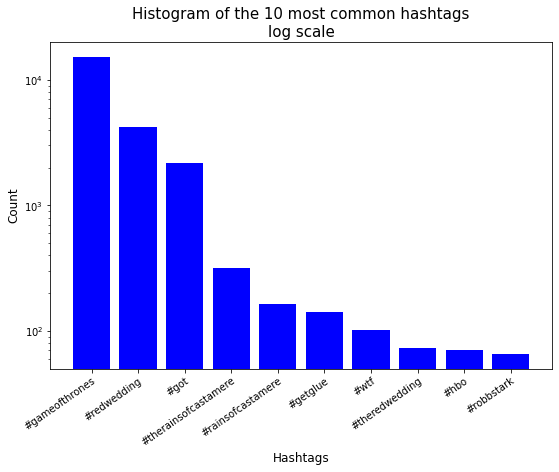

```python
plt.figure(figsize=(9,6))
plt.bar(np.arange(0, num_of_bars), list(hashtag_count.values())[:num_of_bars], color='b')
plt.xticks(np.arange(0, num_of_bars), list(hashtag_count.keys())[:num_of_bars], rotation=35, ha='right', rotation_mode='anchor')
plt.title(f'Histogram of the {num_of_bars} most common hashtags\nlog scale', fontsize=FS+3)
plt.xlabel('Hashtags', fontsize=FS)
plt.ylabel('Count', fontsize=FS)
plt.yscale('log')
plt.show()
```

## Exercise 2

Tokenize the text of the tweets, and gather the 'real' words for each tweet.

By 'real' words, there should be:

- no punctuations
- hashtags only without `#` mark
- no user mentions
- no URLs
- no emojis
- no numbers

Count word occurrences, make a histogram of the occurrences. What are the top words? Are they what you expected?

What crazy words did you get? Explain possible approaches, with which you could throw out this kind of junk text as well.

Removing emojis from a string in python: [StackOverflow](https://stackoverflow.com/questions/33404752/removing-emojis-from-a-string-in-python)

```python
text_flt = text.copy()

# Creating emoji pattern to remove them
emoji_pattern = re.compile("["
                            u"\U0001F600-\U0001F64F"  # emoticons
                            u"\U0001F300-\U0001F5FF"  # symbols & pictographs
                            u"\U0001F680-\U0001F6FF"  # transport & map symbols
                            u"\U0001F1E0-\U0001F1FF"  # flags (iOS)
                                               "]+", flags=re.UNICODE)
filters_pre = ['@', 'http', 'RT']
for i, tw in enumerate(text_flt):
    for f in filters_pre:
        if f in tw:
            tw_tmp = filter(lambda x:f not in x, tw.split())
            tw = " ".join(filter(lambda x:f not in x, tw.split()))
    if '#' in tw:
        tw = tw.replace('#', '')
    text_flt[i] = emoji_pattern.sub(r'', tw)
```

```python
filters = string.digits + string.punctuation

# Choose the top N words from the vocabulary
tokenizer = tf.keras.preprocessing.text.Tokenizer(num_words=None, oov_token="<unk>", filters=filters)
tokenizer.fit_on_texts(text_flt)

# Create the tokenized vectors
text_seqs = tokenizer.texts_to_sequences(text_flt)

# Calculate the legngth of the longest vector
max_length = max([len(t) for t in text_seqs])

word_index = tokenizer.word_index
filtered_hashtag_count = dict(tokenizer.word_counts)

filtered_hashtag_count = sort_a_dict(filtered_hashtag_count)
```

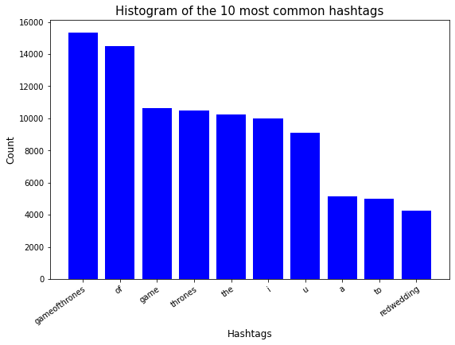

```python
plt.figure(figsize=(9,6))
plt.bar(np.arange(0, num_of_bars), list(filtered_hashtag_count.values())[:num_of_bars], color='b')
plt.xticks(np.arange(0, num_of_bars), list(filtered_hashtag_count.keys())[:num_of_bars], rotation=35, ha='right', rotation_mode='anchor')
plt.title(f'Histogram of the {num_of_bars} most common hashtags', fontsize=FS+3)
plt.xlabel('Hashtags', fontsize=FS)
plt.ylabel('Count', fontsize=FS)
plt.show()
```

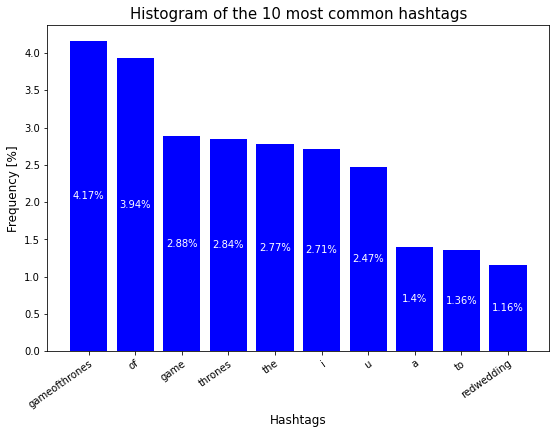

```python
plt.figure(figsize=(9,6))
filtered_hashtag_count_values = np.array(list(filtered_hashtag_count.values()))
word_counts_df_pctg = filtered_hashtag_count_values[:num_of_bars] / np.sum(filtered_hashtag_count_values)
plt.bar(np.arange(0, num_of_bars), word_counts_df_pctg*100, color='b')
for x in range(num_of_bars):
    plt.text(x, word_counts_df_pctg[x]*100/2, f'{np.round(word_counts_df_pctg[x]*100, 2)}%', color='w', horizontalalignment='center', verticalalignment='center')
plt.xticks(np.arange(0, num_of_bars), list(filtered_hashtag_count.keys())[:num_of_bars], rotation=35, ha='right', rotation_mode='anchor')
plt.title(f'Histogram of the {num_of_bars} most common hashtags', fontsize=FS+3)
plt.xlabel('Hashtags', fontsize=FS)
plt.ylabel('Frequency [%]', fontsize=FS)
plt.show()
```

## Exercise 3

Extract the stopword list for the English language with the help of `nltk`. Download the standard Brown Corpus also from `nltk`, count the relative frequency of stopwords in both the Brown Corpus and the GoT tweets. Make a $\text{scatterplot}^1$ of your results, try to explain possible similarities and deviations. What is the correlation in the stopword frequencies of the two datasets?

Dataset: [nltk.org](https://www.nltk.org/howto/corpus.html)

$^1$ I think a histogram will be better.

```python
#import nltk
#nltk.download('brown')
from nltk.corpus import brown as nltk_brown
nltk_brown_words = nltk_brown.words()

print(nltk_brown_words)
```

```
['The', 'Fulton', 'County', 'Grand', 'Jury', 'said', ...]
```

```python
brown_count_words = count_words(nltk_brown_words)
brown_count_words_pctg = count_pctg(brown_count_words)
filtered_hashtag_count_pctg = count_pctg(filtered_hashtag_count)
```

```python
# Selecting key-value pairs with the same key
most_common_same_words = select_same_keys(filtered_hashtag_count_pctg, brown_count_words_pctg)
```

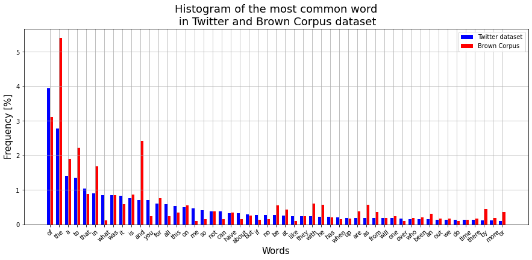

```python
# Extracting the first and second values from the tuples
most_common_same_words_GoT = np.array([v[0] for v in most_common_same_words.values()])*100
most_common_same_words_BC = np.array([v[1] for v in most_common_same_words.values()])*100
words = list(most_common_same_words.keys())

# Creating the positions for the bars
bar_width = 0.35
index = np.arange(len(words))

plt.figure(figsize=(15, 6))
plt.bar(index, most_common_same_words_GoT, bar_width, label='Twitter dataset', color='b')
plt.bar(index + bar_width, most_common_same_words_BC, bar_width, label='Brown Corpus', color='r')
plt.title('Histogram of the most common word\n in Twitter and Brown Corpus dataset', fontsize=FS+6)
plt.xlabel('Words', fontsize=FS+3)
plt.ylabel('Frequency [%]', fontsize=FS+3)
plt.xticks(index+bar_width/2, words, rotation=40)
plt.legend()
plt.grid()
plt.show()
```

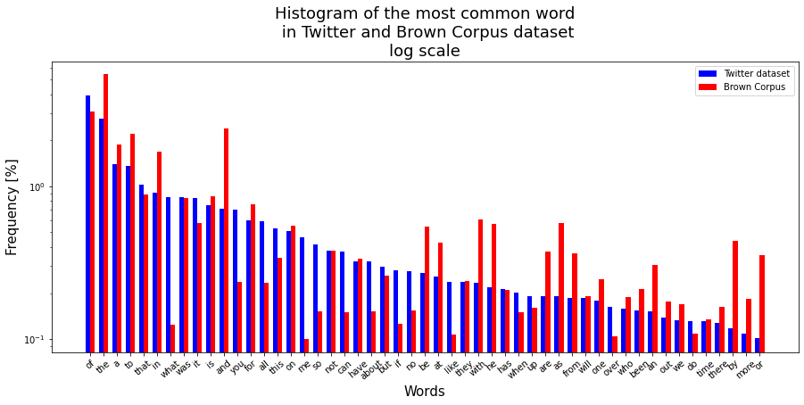

```python
# Extracting the first and second values from the tuples
most_common_same_words_GoT = np.array([v[0] for v in most_common_same_words.values()])*100
most_common_same_words_BC = np.array([v[1] for v in most_common_same_words.values()])*100
words = list(most_common_same_words.keys())

# Creating the positions for the bars
bar_width = 0.35
index = np.arange(len(words))

plt.figure(figsize=(15, 6))
plt.bar(index, most_common_same_words_GoT, bar_width, label='Twitter dataset', color='b')
plt.bar(index + bar_width, most_common_same_words_BC, bar_width, label='Brown Corpus', color='r')
plt.title('Histogram of the most common word\n in Twitter and Brown Corpus dataset\nlog scale', fontsize=FS+6)
plt.xlabel('Words', fontsize=FS+3)
plt.ylabel('Frequency [%]', fontsize=FS+3)
plt.xticks(index+bar_width/2, words, rotation=40)
plt.yscale('log')
plt.legend()
plt.show()
```

## Exercise 4

A really common tool to visualize texts is a wordcloud. Find a suitable library and create a meaningful wordcloud of the GoT tweets (e.g. leave out punctuation, stopwords etc.)

```python
stopwords = set(wordcloud.STOPWORDS)

# Collect the N most common words from the text
N = 200
text_WordCloud = ''
for tw in text_flt:
    text_WordCloud += ' '.join((w for w in tw.split() if(w in list(filtered_hashtag_count.keys())[:N])  and  w not in stopwords))

print (f"There are {text_WordCloud.count(' ')+1} words in the combination of all filtered tweets.")
```

```
There are 28980 words in the combination of all filtered tweets.
```

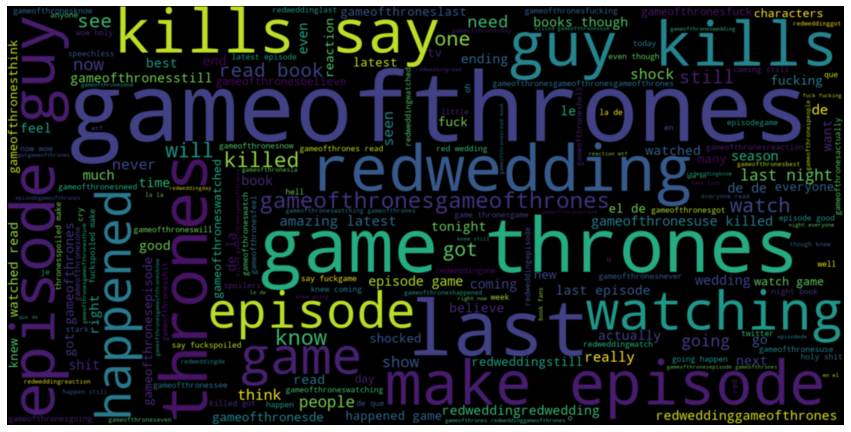

```python
GoT_WordCloud = wordcloud.WordCloud(width=1800, height=900, max_words=200, background_color='black').generate_from_text(text_WordCloud)

# Generate a word cloud image
plt.figure(figsize=(15,15))
plt.imshow(GoT_WordCloud, interpolation='bicubic')
plt.axis('off')
plt.show()
```

## Exercise 5

Define a time window in which all tweets count as one document. Create the term-document matrix of the tweets for this time segmentation. Apply stemming and stopword filtering.

```python
text_flt_2 = text_flt.copy()

for i, txt in enumerate(text_flt):
    txt2 = re.sub(r'[0-9\W_]', ' ', txt)
    tokenizer = TweetTokenizer(strip_handles=False, reduce_len=True)
    tokenized = tokenizer.tokenize(txt2)
    txt_wo_stopwords = [word for word in tokenized if not word in stopwords]
    txt_stemming = []
    for word in txt_wo_stopwords:
        txt_stemming.append(porter().stem(word))
    text_flt_2[i] =  " ".join(txt_stemming)
```

```python
vec = CountVectorizer()
X = vec.fit_transform(text_flt_2)
term_document_mtx = pd.DataFrame(X.toarray(), columns=vec.get_feature_names_out())
term_document_mtx
```

|  | aa | aaa | aaaah | aaaand | aaaargh | aaaarrrggghhh | aaaauuugghh | aaaggghhh | aaaghggg | aaah | ... | zoraki | zorra | zou | zu | zustand | zwaar | zwart | zwrot | zy | zynga |
| --- | --- | --- | --- | --- | --- | --- | --- | --- | --- | --- | --- | --- | --- | --- | --- | --- | --- | --- | --- | --- | --- |
| 0 | 0 | 0 | 0 | 0 | 0 | 0 | 0 | 0 | 0 | 0 | ... | 0 | 0 | 0 | 0 | 0 | 0 | 0 | 0 | 0 | 0 |
| 1 | 0 | 0 | 0 | 0 | 0 | 0 | 0 | 0 | 0 | 0 | ... | 0 | 0 | 0 | 0 | 0 | 0 | 0 | 0 | 0 | 0 |
| 2 | 0 | 0 | 0 | 0 | 0 | 0 | 0 | 0 | 0 | 0 | ... | 0 | 0 | 0 | 0 | 0 | 0 | 0 | 0 | 0 | 0 |
| 3 | 0 | 0 | 0 | 0 | 0 | 0 | 0 | 0 | 0 | 0 | ... | 0 | 0 | 0 | 0 | 0 | 0 | 0 | 0 | 0 | 0 |
| 4 | 0 | 0 | 0 | 0 | 0 | 0 | 0 | 0 | 0 | 0 | ... | 0 | 0 | 0 | 0 | 0 | 0 | 0 | 0 | 0 | 0 |
| ... | ... | ... | ... | ... | ... | ... | ... | ... | ... | ... | ... | ... | ... | ... | ... | ... | ... | ... | ... | ... | ... |
| 27330 | 0 | 0 | 0 | 0 | 0 | 0 | 0 | 0 | 0 | 0 | ... | 0 | 0 | 0 | 0 | 0 | 0 | 0 | 0 | 0 | 0 |
| 27331 | 0 | 0 | 0 | 0 | 0 | 0 | 0 | 0 | 0 | 0 | ... | 0 | 0 | 0 | 0 | 0 | 0 | 0 | 0 | 0 | 0 |
| 27332 | 0 | 0 | 0 | 0 | 0 | 0 | 0 | 0 | 0 | 0 | ... | 0 | 0 | 0 | 0 | 0 | 0 | 0 | 0 | 0 | 0 |
| 27333 | 0 | 0 | 0 | 0 | 0 | 0 | 0 | 0 | 0 | 0 | ... | 0 | 0 | 0 | 0 | 0 | 0 | 0 | 0 | 0 | 0 |
| 27334 | 0 | 0 | 0 | 0 | 0 | 0 | 0 | 0 | 0 | 0 | ... | 0 | 0 | 0 | 0 | 0 | 0 | 0 | 0 | 0 | 0 |

27335 rows × 14366 columns

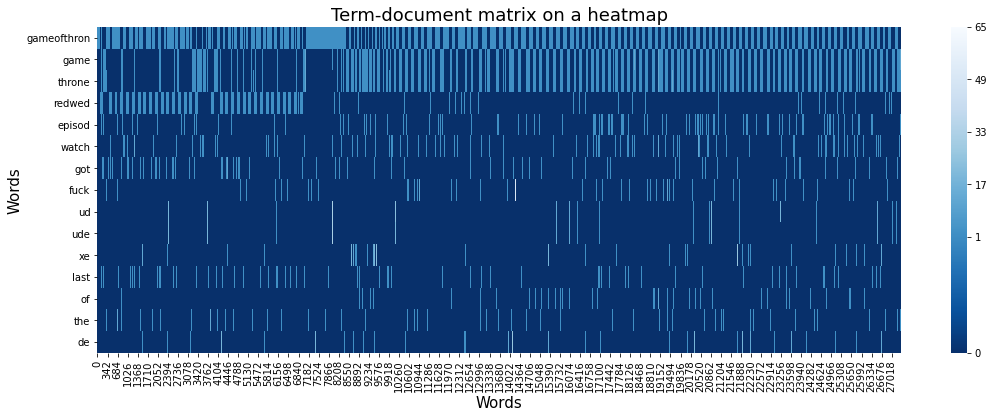

```python
colnames = term_document_mtx.sum().sort_values(ascending=False).index

plt.figure(figsize=(18,6))
ax = sns.heatmap(np.log10(term_document_mtx[colnames[:15]].T+0.1), cmap='Blues_r')
cbar = ax.collections[0].colorbar
cbar.set_ticks(np.append([-1], np.linspace(0, (np.log10(np.max(term_document_mtx[colnames]))), 5)))
cbar.set_ticklabels(np.append([0], np.linspace(1, (np.max(term_document_mtx[colnames])), 5, dtype=int)))
plt.title('Term-document matrix on a heatmap', fontsize=FS+6)
plt.xlabel('Words', fontsize=FS+3)
plt.ylabel('Words', fontsize=FS+3)
plt.show()
```

## Exercise 6

Apply a TF-IDF weighting scheme for the term-document matrix by hand (e.g. do not use a built-in vectorizer, but normalize by text length with a summation etc. `numpy` or `pandas` is strongly suggested). Then, choose a topic detection method such as LSI or LDA, and run it on your matrix. Try to interpret your results! Are your topics meaningful? Which topics are the most representative of your document?

```python
# Calculate TF
tf = term_document_mtx / np.sum(term_document_mtx, axis=0)

# Calculate IDF
N = term_document_mtx.shape[1]  # Total number of documents
df = np.count_nonzero(term_document_mtx, axis=1)  # Number of documents containing each term
idf = np.log(N / (df+1))

# Calculate TF-IDF
tf_idf = tf * idf[:, np.newaxis]

# Print TF-IDF matrix
print("TF-IDF Matrix:")
tf_idf[colnames[:15]]
```

```
TF-IDF Matrix:
```

|  | gameofthron | game | throne | redwed | episod | watch | got | fuck | ud | ude | xe | last | of | the | de |
| --- | --- | --- | --- | --- | --- | --- | --- | --- | --- | --- | --- | --- | --- | --- | --- |
| 0 | 0.000519 | 0.000000 | 0.000000 | 0.0 | 0.000000 | 0.002679 | 0.00000 | 0.0 | 0.0 | 0.0 | 0.0 | 0.000000 | 0.0 | 0.0 | 0.0 |
| 1 | 0.000452 | 0.000000 | 0.000000 | 0.0 | 0.000000 | 0.000000 | 0.00000 | 0.0 | 0.0 | 0.0 | 0.0 | 0.000000 | 0.0 | 0.0 | 0.0 |
| 2 | 0.000480 | 0.000000 | 0.000000 | 0.0 | 0.000000 | 0.000000 | 0.00000 | 0.0 | 0.0 | 0.0 | 0.0 | 0.000000 | 0.0 | 0.0 | 0.0 |
| 3 | 0.000447 | 0.000000 | 0.000000 | 0.0 | 0.002204 | 0.000000 | 0.00000 | 0.0 | 0.0 | 0.0 | 0.0 | 0.003774 | 0.0 | 0.0 | 0.0 |
| 4 | 0.000480 | 0.000000 | 0.000000 | 0.0 | 0.000000 | 0.000000 | 0.00277 | 0.0 | 0.0 | 0.0 | 0.0 | 0.000000 | 0.0 | 0.0 | 0.0 |
| ... | ... | ... | ... | ... | ... | ... | ... | ... | ... | ... | ... | ... | ... | ... | ... |
| 27330 | 0.000000 | 0.000693 | 0.000703 | 0.0 | 0.002368 | 0.000000 | 0.00000 | 0.0 | 0.0 | 0.0 | 0.0 | 0.000000 | 0.0 | 0.0 | 0.0 |
| 27331 | 0.000000 | 0.000704 | 0.000714 | 0.0 | 0.000000 | 0.000000 | 0.00000 | 0.0 | 0.0 | 0.0 | 0.0 | 0.000000 | 0.0 | 0.0 | 0.0 |
| 27332 | 0.000000 | 0.000683 | 0.000693 | 0.0 | 0.000000 | 0.002445 | 0.00000 | 0.0 | 0.0 | 0.0 | 0.0 | 0.000000 | 0.0 | 0.0 | 0.0 |
| 27333 | 0.000000 | 0.000683 | 0.000693 | 0.0 | 0.000000 | 0.002445 | 0.00000 | 0.0 | 0.0 | 0.0 | 0.0 | 0.000000 | 0.0 | 0.0 | 0.0 |
| 27334 | 0.000000 | 0.000683 | 0.000693 | 0.0 | 0.000000 | 0.002445 | 0.00000 | 0.0 | 0.0 | 0.0 | 0.0 | 0.000000 | 0.0 | 0.0 | 0.0 |

27335 rows × 15 columns

```python
LDA = LatentDirichletAllocation(n_components=3, n_jobs=-1)
Transform = LDA.fit_transform(term_document_mtx)
Componets = LDA.components_

Componets_df = pd.DataFrame()
Componets_df['Words'] = term_document_mtx.columns
Componets_df['Weight in topic 1'] = Componets[0]
Componets_df['Weight in topic 2'] = Componets[1]
Componets_df['Weight in topic 3'] = Componets[2]
```

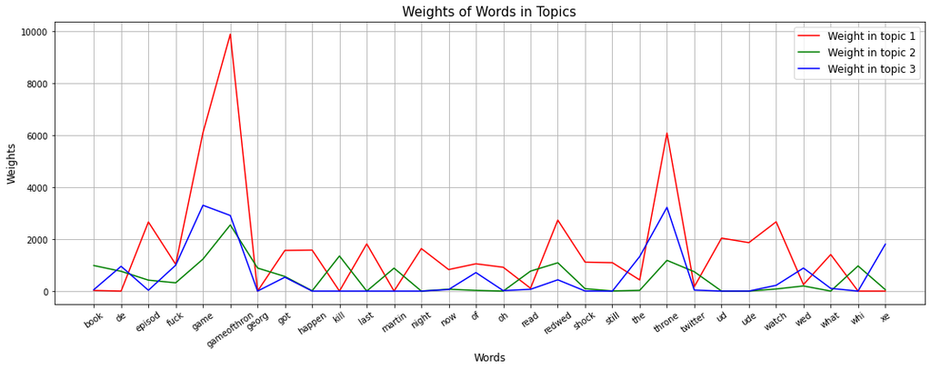

```python
W_df_short = Componets_df[Componets_df['Words'].isin(colnames[:30])]
plt.figure(figsize=(18,6))
plt.plot(W_df_short['Words'], W_df_short['Weight in topic 1'], label='Weight in topic 1', c='r')
plt.plot(W_df_short['Words'], W_df_short['Weight in topic 2'], label='Weight in topic 2', c='g')
plt.plot(W_df_short['Words'], W_df_short['Weight in topic 3'], label='Weight in topic 3', c='b')
plt.title('Weights of Words in Topics', fontsize=FS+3)
plt.xlabel('Words', fontsize=FS)
plt.ylabel('Weights', fontsize=FS)
plt.legend(fontsize=FS)
plt.xticks(W_df_short['Words'], rotation=35)
plt.grid()
plt.show()
```

The most reprensentative words are related to the GoT as we expected.

# Optional exercises

## Exercise 7 - optional

Write an own name parser for the tweets, and consider all names that you find in the dataset as a node of a graph. Add 1 to the weight of an edge if two names occur in the same tweet. With the help of networkx, draw the weighted network of names from the text. Try to find a simple clustering algorithm in networkx, cluster the names in the dataset. Print or visualize your results!

## Exercise 8 - optional

This episode caused severe disappointments in many viewers, because of the sudden death of too many of the favourite characters. Search for some sentiment analysis method, and create a timeline of sentiments based on the tweet texts. Do the sentiments on Twitter reflect the time of the worst scene?